# Analysis of Dataset B

2025-02-06

## Dimension of the dataset

```r
cat("The dataset has", nrow(HLA_discov_et_validation_431), "rows and", ncol(HLA_discov_et_validation_431), "columns.\n")
```

```
## The dataset has 431 rows and 23 columns.
```

## Structure of the dataset

To highlight the variables:

```r
str(HLA_discov_et_validation_431)
```

All the variables, divided by type

### 1. Demographic and Lifestyle Data

- **numIM**: Identification of the patient → no analysis
- **Age**: Patient’s age in years
- **Sex**: Patient’s sex
- **Smoking history**: Patient’s smoking history
- **histology**: Histologic type of the tumor

### 2. Disease Progression and Survival Data

- **os_status**: Overall survival status of the patient
- **osduree**: Overall survival duration
- **pfsduree_immunoth**: Progression-Free Survival (PFS), duration without the progression of the tumor under immunotherapy

### 3. Immunotherapy Data

- **Immuno Line**: Line of immunotherapy treatment received
- **nb_meta_beforeimmuno**: Number of metastases detected before immunotherapy
- **ps_befimmuno**: Performance Status before the treatment

### 4. Therapy Response

- **ipd_status**: Indicates whether the patient developed immunotherapy-related disease progression
- **dcr**: Disease control rate
- **iORR**: Objective response rate

### 5. Biologic Parameters

- **LeucoTpre**: Total white blood cell count before treatment
- **NeutTpre**: Total neutrophil count before treatment
- **LDHpre**: Lactate dehydrogenase (LDH) levels before treatment
- **dNLR**: Derived neutrophil-to-lymphocyte ratio
- **dNLR_categ**: Classification of D-NLR into categories
- **dNLR_pre_lipi**: ? → no analysis
- **LDH_lipi**: ? → no analysis
- **LDH_categ**: Classification of pre-treatment LDH levels
- **lipi_pre**: Score of Lipi-Index, a score that combines LDH and dNLR

## Pre-processing

To a better use of the dataset, a normalization of the names of the columns/variables is preferible

```r
library(dplyr)
library(data.table)

HLA_discov_et_validation_431 <- HLA_discov_et_validation_431 %>%
 rename_with(~ tolower(.) %>%              #better using lowercase characters
                gsub(" ", "_", .) %>%      #better using underscores instead of whitespaces
                gsub("-", "_", .) %>%      #better removing special characters (-)
                gsub("\\(|\\)", "", .))    #better removing special characters (())
```

## Statistic summary

```r
summary(HLA_discov_et_validation_431)
```

## Missing values

### How many missing values are in the dataset?

It’s important to check how many NA’s values are in the dataset.

```r
sum(is.na(HLA_discov_et_validation_431))
```

```
## [1] 89
```

### How to handle the missing values?

Now, to understand what are the best suitable techniques to use to manage the NA’s values, I check for each column (first) and for each row (after) the percentage of missing values

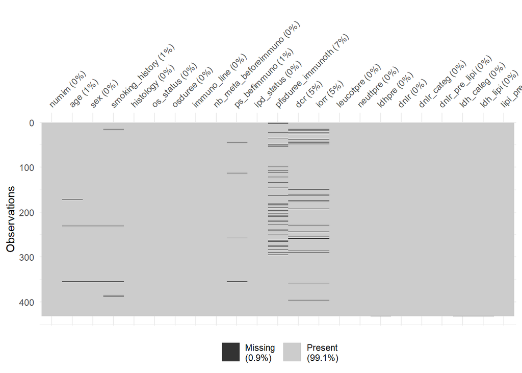

```r
library(naniar)
vis_miss(HLA_discov_et_validation_431)
```

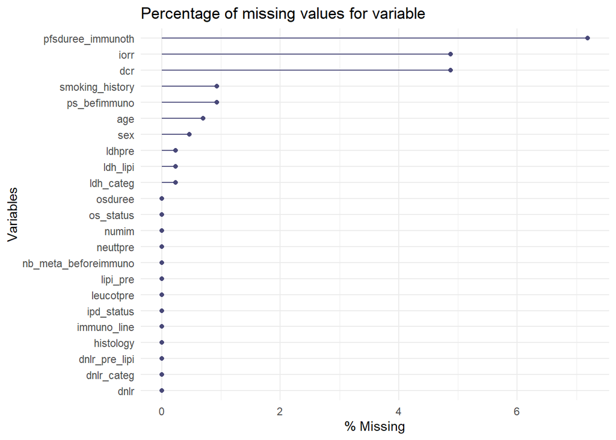

```r
library(dplyr)
library(ggplot2)
#FOR COLUMNS
gg_miss_var(HLA_discov_et_validation_431, show_pct = TRUE) +
  labs(title = "Percentage of missing values for variable") +
  theme_minimal()
```

```r
missing_values <- colSums(is.na(HLA_discov_et_validation_431))


missing_percentage <- (missing_values / nrow(HLA_discov_et_validation_431)) * 100


missing_report <- data.frame(
  column = names(HLA_discov_et_validation_431),
  missing_values = missing_values,
  missing_percentage = missing_percentage
) %>%
  arrange(desc(missing_percentage))

num_columns_above_40 <- sum(missing_report$missing_percentage > 40)
print(paste("Number of columns with missing percentage > 40%:", num_columns_above_40))
```

```
## [1] "Number of columns with missing percentage > 40%: 0"
```

```r
#VERY CONSISTENT DATASET (the highest percentage (of missing values) is 7 %)
```

Since is useless, i eliminate it

```r
col_useless <- c("numim")
HLA_discov_et_validation_431 <- HLA_discov_et_validation_431 %>%
  select(-all_of(col_useless))
```

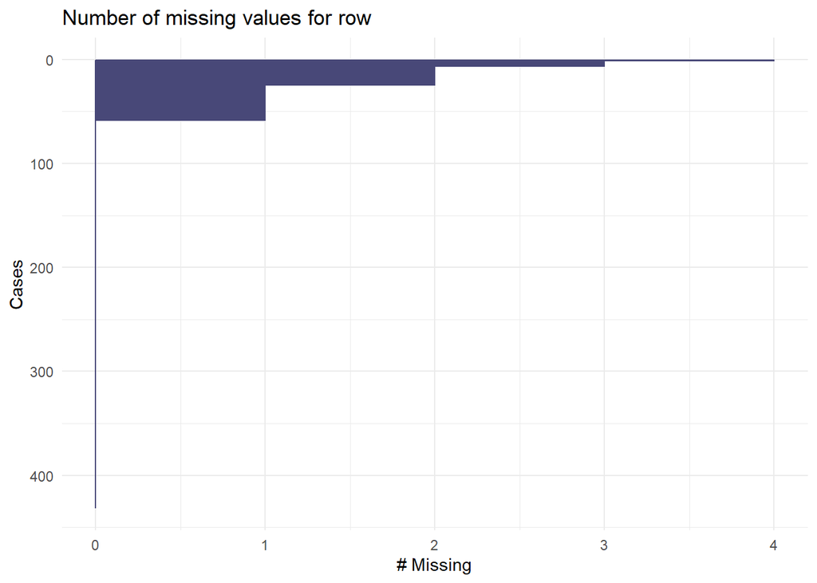

```r
# FOR ROWS
gg_miss_case(HLA_discov_et_validation_431) +
  labs(title = "Number of missing values for row") +
  theme_minimal()
```

```r
missing_values <- rowSums(is.na(HLA_discov_et_validation_431))

missing_percentage <- (missing_values / ncol(HLA_discov_et_validation_431)) * 100

missing_report <- data.frame(
  row = 1:nrow(HLA_discov_et_validation_431),
  missing_values = missing_values,
  missing_percentage = missing_percentage
) %>%
  arrange(desc(missing_percentage))

num_rows_above_50 <- sum(missing_report$missing_percentage > 50)
print(paste("Number of rows with missing percentage > 50%:", num_rows_above_50))
```

```
## [1] "Number of rows with missing percentage > 50%: 0"
```

```r
#AS FOR THE COLUMNS (the highest percentage is 17%)
```

## Types of variables

So in the end how many types of variables we have ?

```r
table(sapply(HLA_discov_et_validation_431, class))
```

```
##
## character   numeric
##        10        12
```

### Analysis of the numeric variables

```r
is_binary_with_na <- function(x) {
  unique_vals <- unique(x[!is.na(x)])
  all(unique_vals %in% c(0, 1))
}
binary_cols <- colnames(HLA_discov_et_validation_431)[sapply(HLA_discov_et_validation_431, is_binary_with_na)]
```

```r
num_var <- HLA_discov_et_validation_431[, sapply(HLA_discov_et_validation_431, is.numeric)]
num_var <- num_var[, !(colnames(num_var) %in% binary_cols)]
```

**AGE**

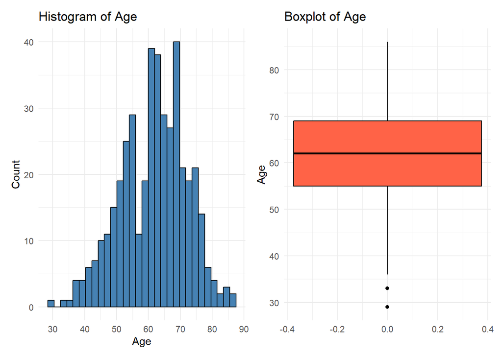

```r
library(ggplot2)
library(patchwork)
num_var <- num_var[!is.na(num_var$age), ]
# Histogram
hist_plot <- ggplot(num_var, aes(x = age)) +
  geom_histogram(fill = "steelblue", color = "black", bins = 30) +
  labs(title = "Histogram of Age", x = "Age", y = "Count") +
  theme_minimal()

# Boxplot
box_plot <- ggplot(num_var, aes(x = age)) +
  geom_boxplot(fill = "tomato", color = "black", outlier.shape = 19) +
  coord_flip() +
  labs(title = "Boxplot of Age", x = "Age", y = "") +
  theme_minimal()

hist_plot + box_plot
```

**IMMUNO LINE**

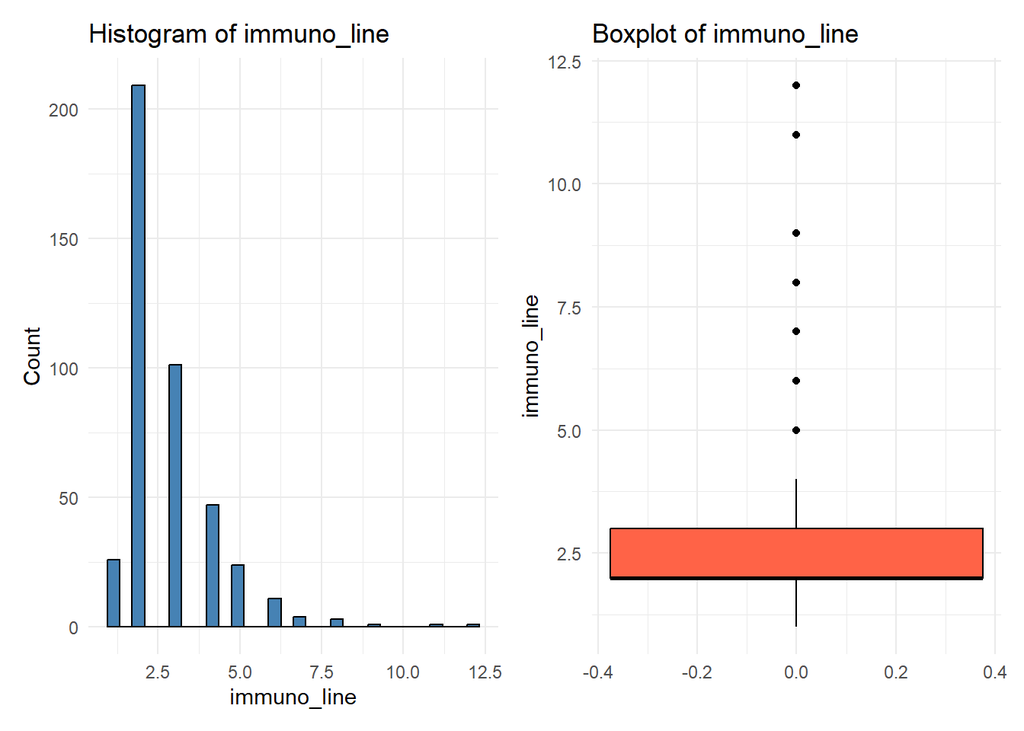

```r
num_var <- num_var[!is.na(num_var$immuno_line), ]
# Histogram
hist_plot <- ggplot(num_var, aes(x = immuno_line)) +
  geom_histogram(fill = "steelblue", color = "black", bins = 30) +
  labs(title = "Histogram of immuno_line", x = "immuno_line", y = "Count") +
  theme_minimal()

# Boxplot
box_plot <- ggplot(num_var, aes(x = immuno_line)) +
  geom_boxplot(fill = "tomato", color = "black", outlier.shape = 19) +
  coord_flip() +
  labs(title = "Boxplot of immuno_line", x = "immuno_line", y = "") +
  theme_minimal()

hist_plot + box_plot
```

**NUMBER OF METASTASES BEFORE IMMUNO**

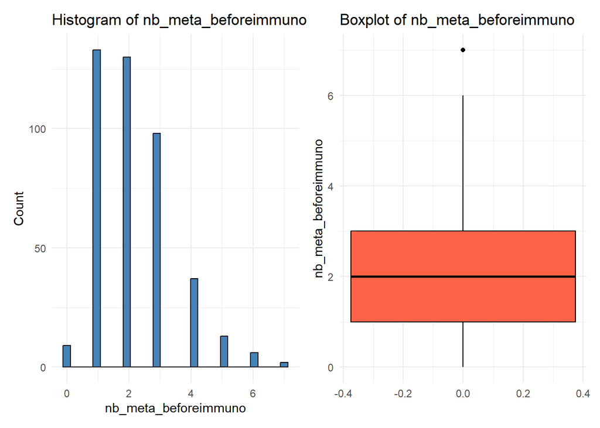

```r
num_var <- num_var[!is.na(num_var$nb_meta_beforeimmuno), ]
# Histogram
hist_plot <- ggplot(num_var, aes(x = nb_meta_beforeimmuno)) +
  geom_histogram(fill = "steelblue", color = "black", bins = 30) +
  labs(title = "Histogram of nb_meta_beforeimmuno", x = "nb_meta_beforeimmuno", y = "Count") +
  theme_minimal()

# Boxplot
box_plot <- ggplot(num_var, aes(x = nb_meta_beforeimmuno)) +
  geom_boxplot(fill = "tomato", color = "black", outlier.shape = 19) +
  coord_flip() +
  labs(title = "Boxplot of nb_meta_beforeimmuno", x = "nb_meta_beforeimmuno", y = "") +
  theme_minimal()

hist_plot + box_plot
```

**PERFORMANCE STATUS BEFORE IMMUNO**

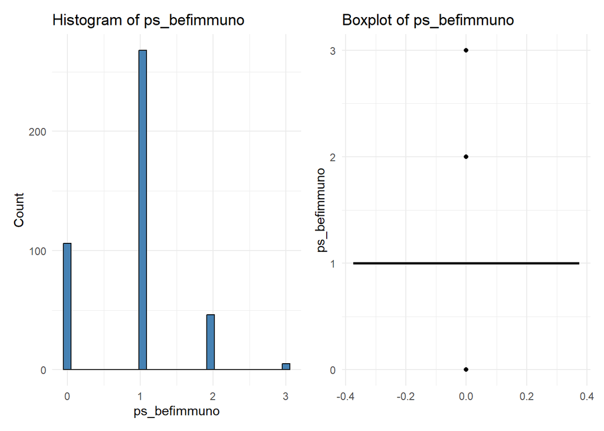

```r
num_var <- num_var[!is.na(num_var$ps_befimmuno), ]
# Histogram
hist_plot <- ggplot(num_var, aes(x = ps_befimmuno)) +
  geom_histogram(fill = "steelblue", color = "black", bins = 30) +
  labs(title = "Histogram of ps_befimmuno", x = "ps_befimmuno", y = "Count") +
  theme_minimal()

# Boxplot
box_plot <- ggplot(num_var, aes(x = ps_befimmuno)) +
  geom_boxplot(fill = "tomato", color = "black", outlier.shape = 19) +
  coord_flip() +
  labs(title = "Boxplot of ps_befimmuno", x = "ps_befimmuno", y = "") +
  theme_minimal()

hist_plot + box_plot
```

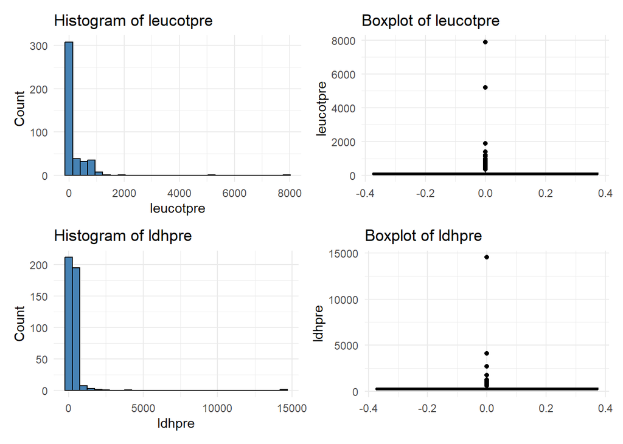

```r
num_var <- num_var[!is.na(num_var$leucotpre), ]
# Histogram
hist_plot1 <- ggplot(num_var, aes(x = leucotpre)) +
  geom_histogram(fill = "steelblue", color = "black", bins = 30) +
  labs(title = "Histogram of leucotpre", x = "leucotpre", y = "Count") +
  theme_minimal()

# Boxplot
box_plot1 <- ggplot(num_var, aes(x = leucotpre)) +
  geom_boxplot(fill = "tomato", color = "black", outlier.shape = 19) +
  coord_flip() +
  labs(title = "Boxplot of leucotpre", x = "leucotpre", y = "") +
  theme_minimal()

num_var <- num_var[!is.na(num_var$ldhpre), ]
# Histogram
hist_plot2 <- ggplot(num_var, aes(x = ldhpre)) +
  geom_histogram(fill = "steelblue", color = "black", bins = 30) +
  labs(title = "Histogram of ldhpre", x = "ldhpre", y = "Count") +
  theme_minimal()

# Boxplot
box_plot2 <- ggplot(num_var, aes(x = ldhpre)) +
  geom_boxplot(fill = "tomato", color = "black", outlier.shape = 19) +
  coord_flip() +
  labs(title = "Boxplot of ldhpre", x = "ldhpre", y = "") +
  theme_minimal()

(hist_plot1 | box_plot1) /
(hist_plot2 | box_plot2)
```

**iPD**

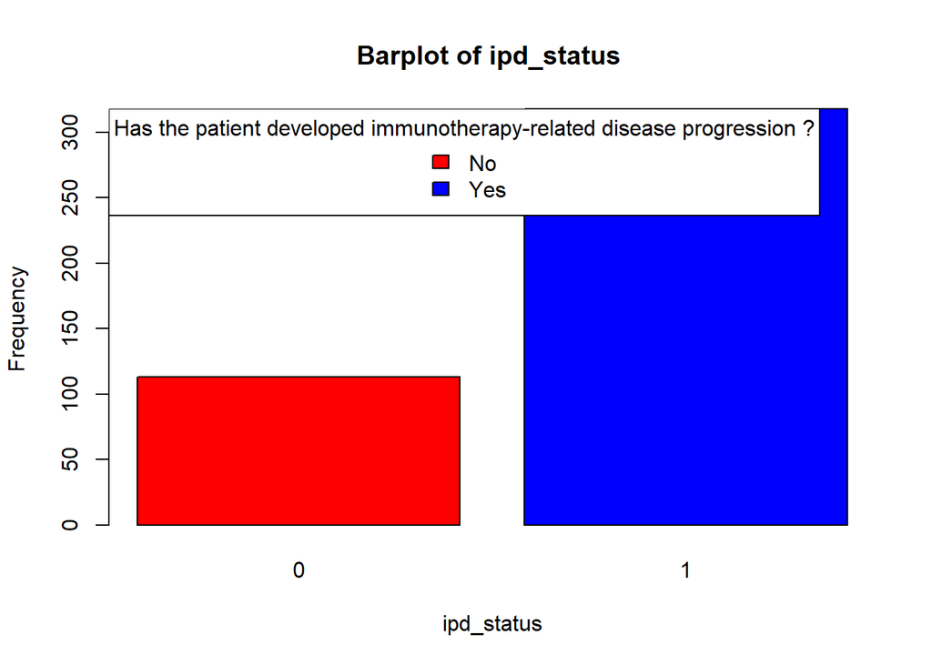

```r
counts <- table(HLA_discov_et_validation_431$ipd_status, useNA = "no")


colors <- c("red", "blue")
category_labels <- c("No", "Yes")

barplot(counts,
            col = colors,
            main = "Barplot of ipd_status ",
            xlab = "ipd_status",
            ylab = "Frequency",
            names.arg = names(counts),
            border = "black")


legend("topleft",
           legend = category_labels,
           fill = colors,
           title = "Has the patient developed immunotherapy-related disease progression ?",
           border = "black")
```

**OS STATUS**

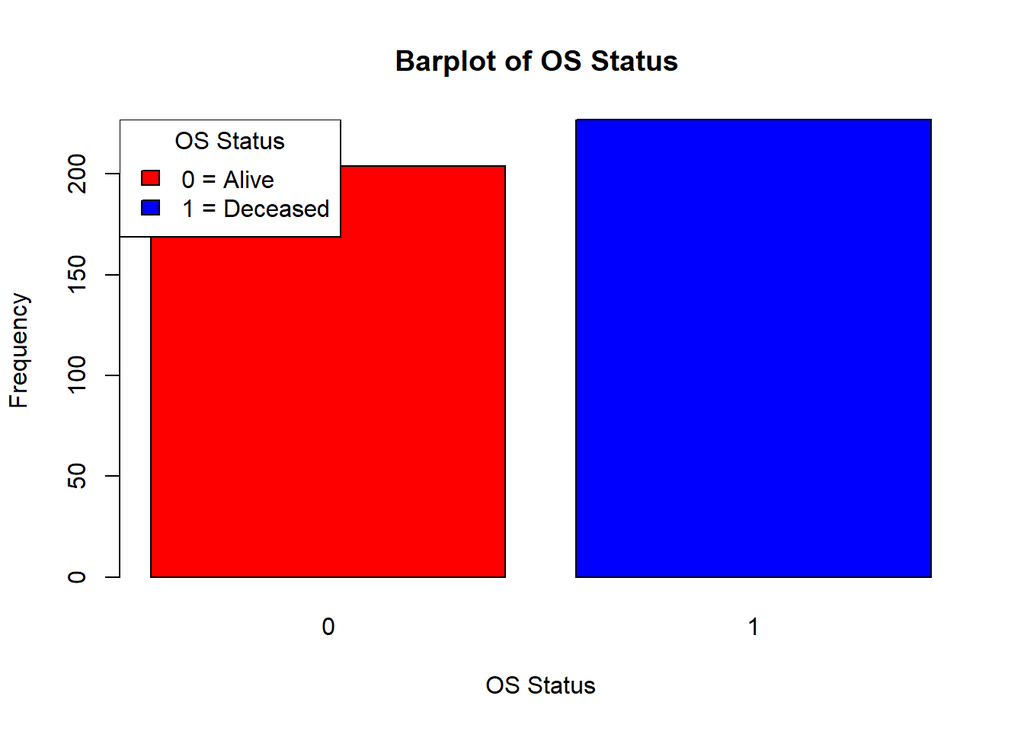

```r
counts <- table(HLA_discov_et_validation_431$os_status, useNA = "no")


colors <- c("red", "blue")

barplot(counts,
            col = colors,
            main = "Barplot of OS Status ",
            xlab = "OS Status",
            ylab = "Frequency",
            names.arg = names(counts),
            border = "black")


legend("topleft",
           legend = c("0 = Alive", "1 = Deceased"),
           fill = colors,
           title = "OS Status",
           border = "black")
```

**DCR**

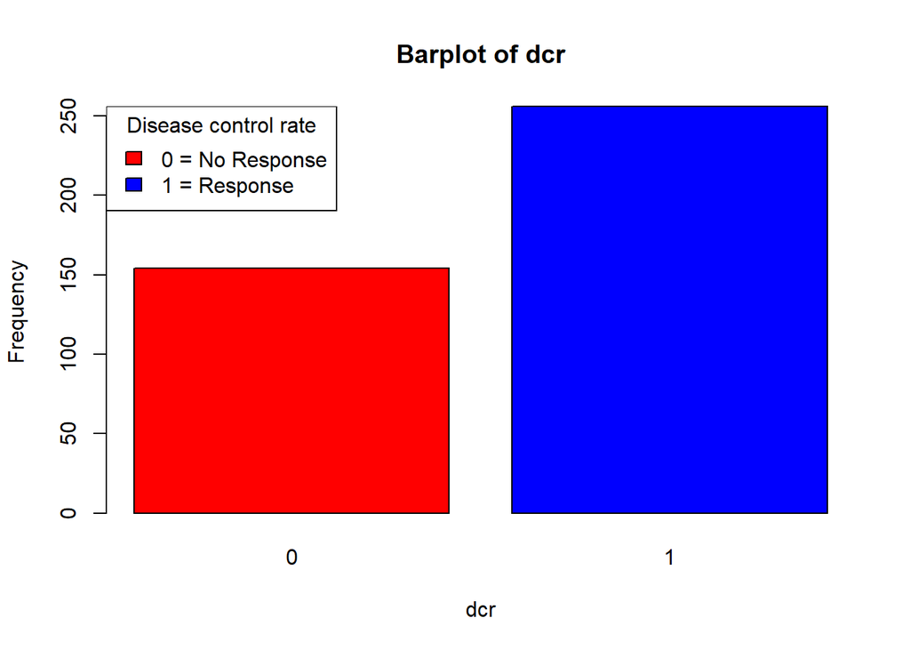

```r
counts <- table(HLA_discov_et_validation_431$dcr, useNA = "no")

colors <- c("red", "blue")

barplot(counts,
            col = colors,
            main = "Barplot of dcr",
            xlab = "dcr",
            ylab = "Frequency",
            names.arg = names(counts),
            border = "black")


legend("topleft",
           legend = c("0 = No Response", "1 = Response"),
           fill = colors,
           title = "Disease control rate",
           border = "black")
```

**i0RR**

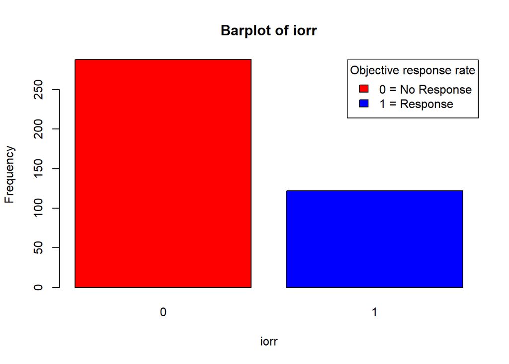

```r
counts <- table(HLA_discov_et_validation_431$iorr, useNA = "no")

colors <- c("red", "blue")

barplot(counts,
            col = colors,
            main = "Barplot of iorr",
            xlab = "iorr",
            ylab = "Frequency",
            names.arg = names(counts),
            border = "black")


legend("topright",
           legend = c("0 = No Response", "1 = Response"),
           fill = colors,
           title = "Objective response rate",
           border = "black")
```

###Analysis of the categorial variables

```r
cat_var <- HLA_discov_et_validation_431[, sapply(HLA_discov_et_validation_431, function(x) is.factor(x) | is.character(x))]

HLA_discov_et_validation_431[, colnames(cat_var)] <- lapply(cat_var, as.factor)
```

**SEX**

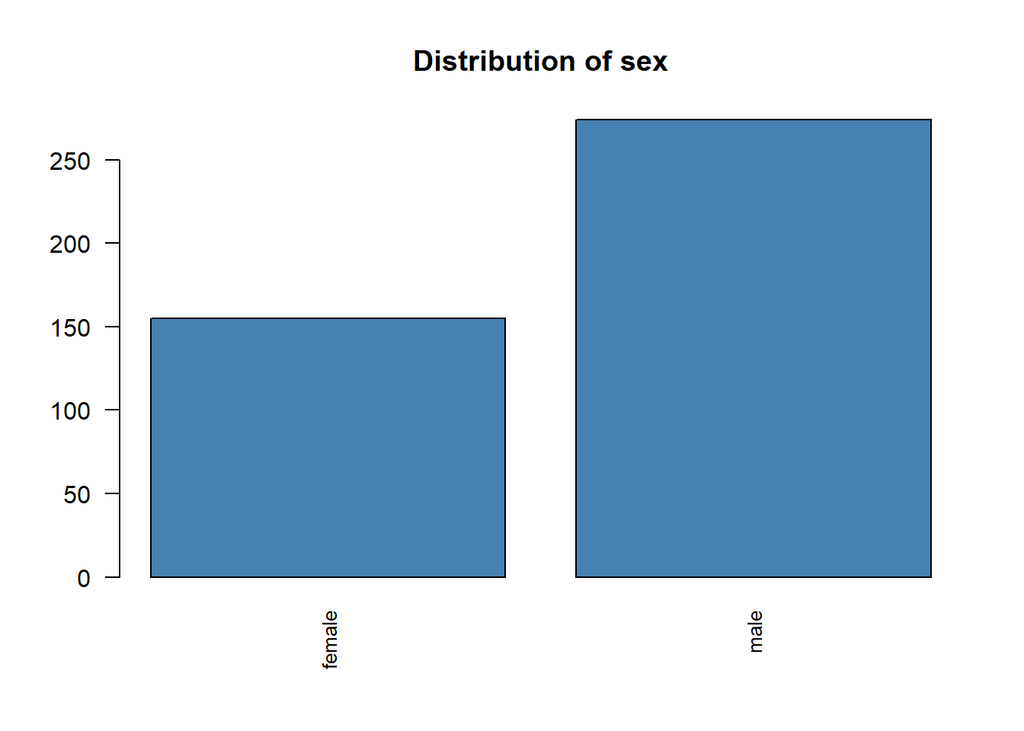

```r
par(mfrow = c(1, 1))
freq_table <- table(HLA_discov_et_validation_431$sex)
  barplot(freq_table,
          main = "Distribution of sex",
          col = "steelblue",
          border = "black",
          las = 2, cex.names = 0.8)
```

**SMOKING HISTORY**

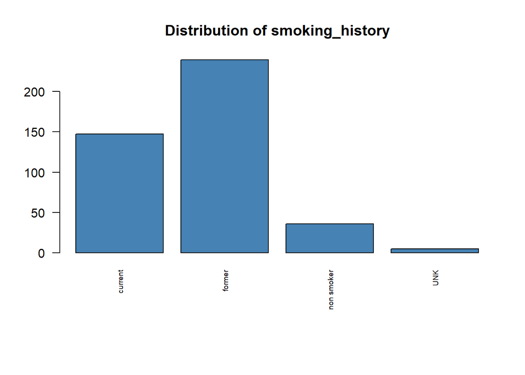

```r
HLA_discov_et_validation_431 <- HLA_discov_et_validation_431 %>%
  mutate(smoking_history = case_when(
    smoking_history == "CURRENT" ~ "current",
    smoking_history == "FORMER" ~ "former",
    smoking_history == "NON SMOKER" ~ "non smoker",
    TRUE ~ smoking_history
  ))
par(mfrow = c(1, 1), mar = c(8, 4, 4, 2))
freq_table <- table(HLA_discov_et_validation_431$smoking_history)
  barplot(freq_table,
          main = "Distribution of smoking_history",
          col = "steelblue",
          border = "black",
          las = 2, cex.names = 0.6)
```

**HISTOLOGY**

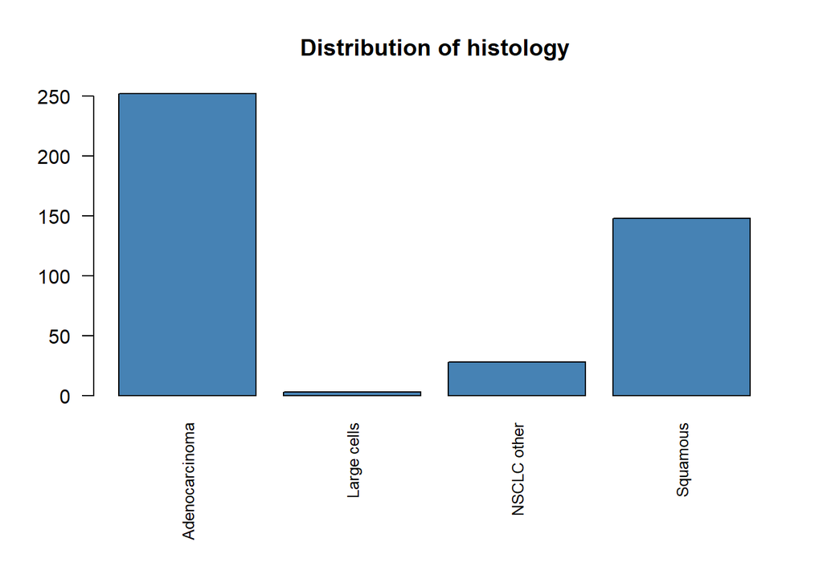

```r
HLA_discov_et_validation_431 <- HLA_discov_et_validation_431 %>%
  mutate(histology = case_when(
    histology == "NSCLC- other" ~ "NSCLC other",
    histology == "NSCLC Other" ~ "NSCLC other",
    TRUE ~ histology
  ))
par(mfrow = c(1, 1), mar = c(8, 4, 4, 2))
freq_table <- table(HLA_discov_et_validation_431$histology)
  barplot(freq_table,
          main = "Distribution of histology",
          col = "steelblue",
          border = "black",
          las = 2, cex.names = 0.8)
```

**iOS DURATION**

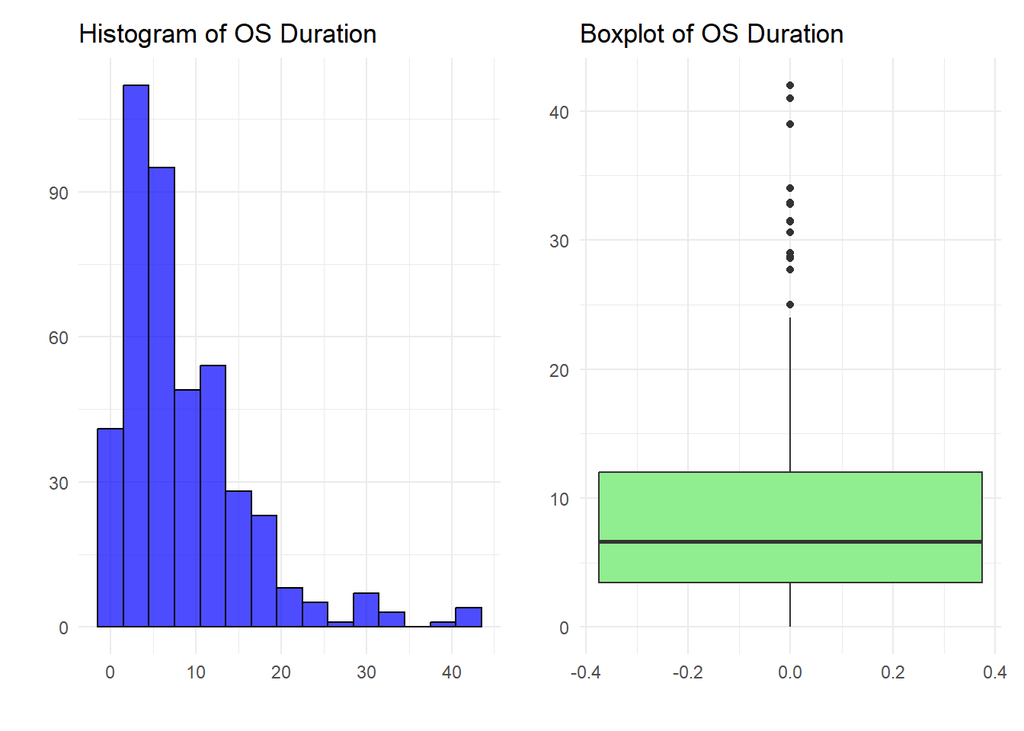

```r
library(ggplot2)
HLA_discov_et_validation_431$osduree <- as.numeric(gsub(",", ".", HLA_discov_et_validation_431$osduree))
hist_plot <- ggplot(HLA_discov_et_validation_431, aes(x = osduree)) +
  geom_histogram(fill = "blue", color = "black", binwidth = 3, alpha = 0.7) +
  labs(title = "Histogram of OS Duration", x = "", y = "") +
  theme_minimal()


box_plot <- ggplot(HLA_discov_et_validation_431, aes(y = osduree)) +
  geom_boxplot(fill = "lightgreen") +
  labs(title = "Boxplot of OS Duration", y = "") +
  theme_minimal()
(hist_plot | box_plot)
```

**iPFS DURATION**

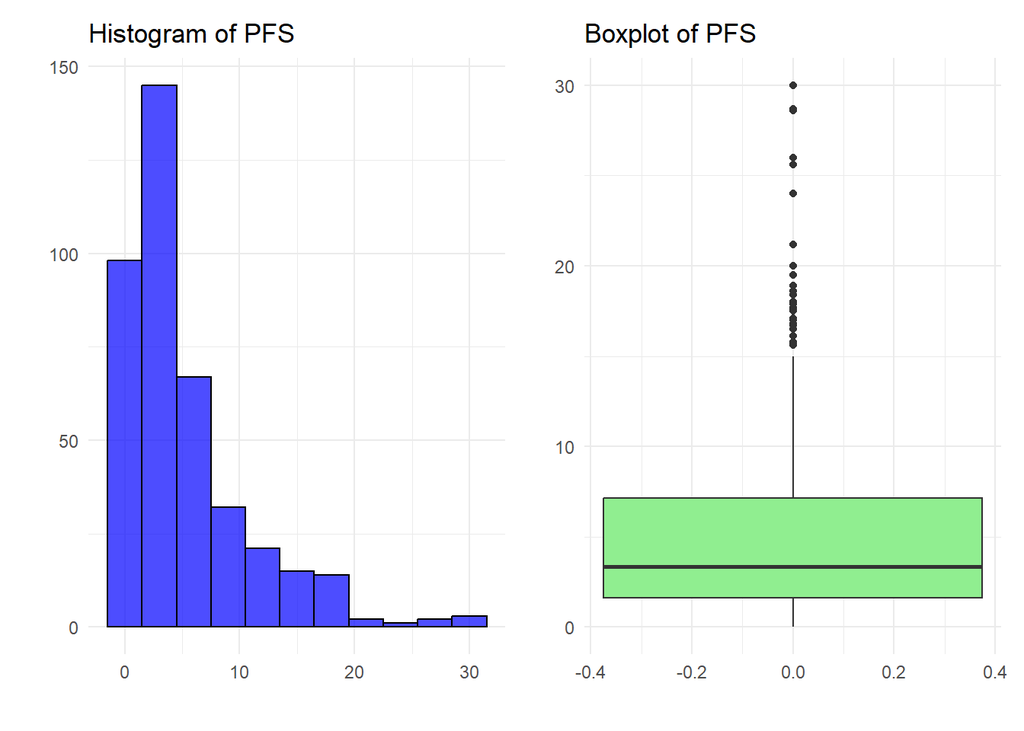

```r
HLA_discov_et_validation_431$pfsduree_immunoth <- as.numeric(gsub(",", ".", HLA_discov_et_validation_431$pfsduree_immunoth))
hist_plot <- ggplot(HLA_discov_et_validation_431, aes(x = pfsduree_immunoth)) +
  geom_histogram(fill = "blue", color = "black", binwidth = 3, alpha = 0.7) +
  labs(title = "Histogram of PFS", x = "", y = "") +
  theme_minimal()

box_plot <- ggplot(HLA_discov_et_validation_431, aes(y = pfsduree_immunoth)) +
  geom_boxplot(fill = "lightgreen") +
  labs(title = "Boxplot of PFS", y = "") +
  theme_minimal()
(hist_plot | box_plot)
```

**NEUTROPHIL AND DERIVED NEUTROPHIL-TO-LYMPHOCYTE RATIO (ONLY) BEFORE**

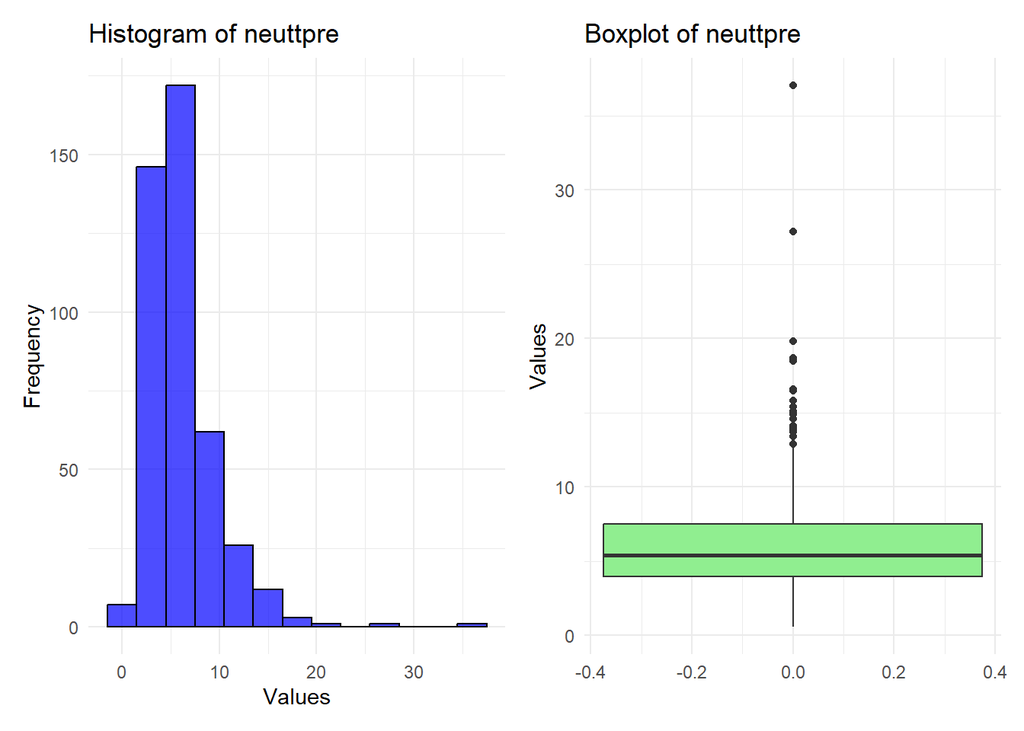

```r
HLA_discov_et_validation_431$neuttpre <- as.numeric(gsub(",", ".", HLA_discov_et_validation_431$neuttpre))
hist_plot <- ggplot(HLA_discov_et_validation_431, aes(x = neuttpre)) +
  geom_histogram(fill = "blue", color = "black", binwidth = 3, alpha = 0.7) +
  labs(title = "Histogram of neuttpre", x = "Values", y = "Frequency") +
  theme_minimal()

box_plot <- ggplot(HLA_discov_et_validation_431, aes(y = neuttpre)) +
  geom_boxplot(fill = "lightgreen") +
  labs(title = "Boxplot of neuttpre", y = "Values") +
  theme_minimal()
(hist_plot | box_plot)
```

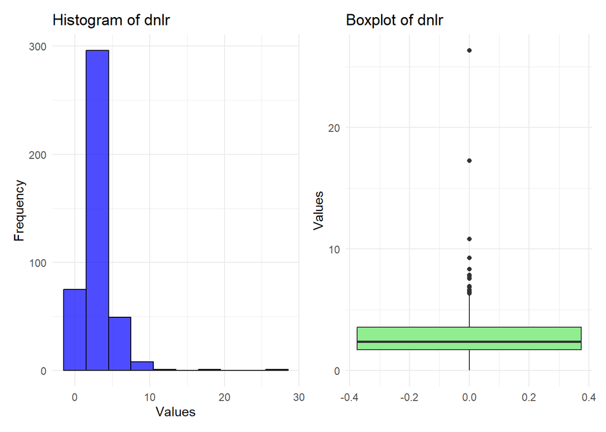

```r
HLA_discov_et_validation_431$dnlr <- as.numeric(gsub(",", ".", HLA_discov_et_validation_431$dnlr))
hist_plot <- ggplot(HLA_discov_et_validation_431, aes(x = dnlr)) +
  geom_histogram(fill = "blue", color = "black", binwidth = 3, alpha = 0.7) +
  labs(title = "Histogram of dnlr", x = "Values", y = "Frequency") +
  theme_minimal()

box_plot <- ggplot(HLA_discov_et_validation_431, aes(y = dnlr)) +
  geom_boxplot(fill = "lightgreen") +
  labs(title = "Boxplot of dnlr", y = "Values") +
  theme_minimal()
(hist_plot | box_plot)
```

**DERIVED NEUTROPHIL-TO-LYMPHOCYTE RATIO CAREGORY AND LDH CATEGORY (ONLY) BEFORE**

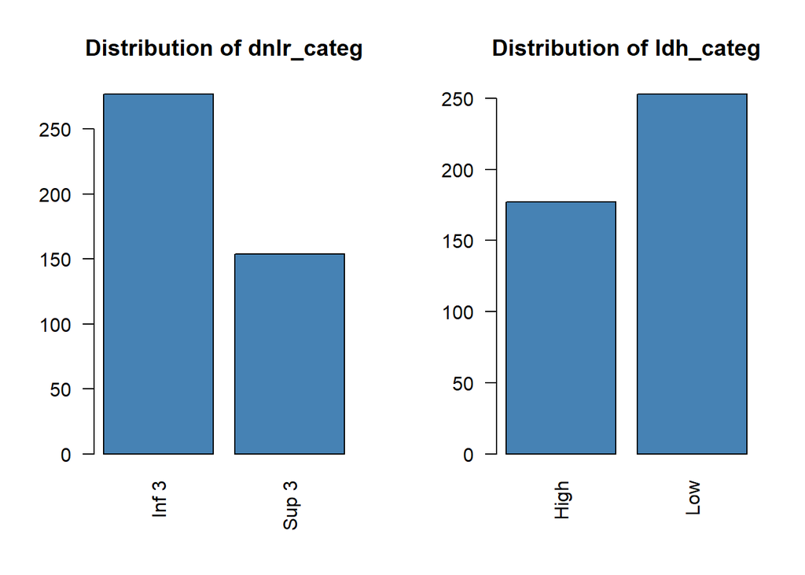

```r
par(mfrow = c(1, 2))
freq_table <- table(HLA_discov_et_validation_431$dnlr_categ)
  barplot(freq_table,
          main = "Distribution of dnlr_categ",
          col = "steelblue",
          border = "black",
          las = 2)

freq_table <- table(HLA_discov_et_validation_431$ldh_categ)
  barplot(freq_table,
          main = "Distribution of ldh_categ",
          col = "steelblue",
          border = "black",
          las = 2)
```

**LIPI (ONLY) BEFORE**

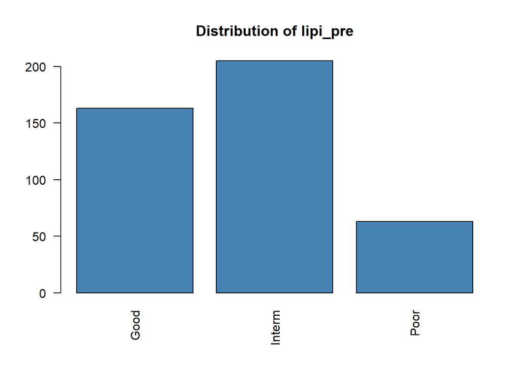

```r
par(mfrow = c(1, 1))
freq_table <- table(HLA_discov_et_validation_431$lipi_pre)
  barplot(freq_table,
          main = "Distribution of lipi_pre",
          col = "steelblue",
          border = "black",
          las = 2)
```